# Assignment 2 - Part B (SVM_DT)

## Nayan Arora - u3249907

## 1. Decision Trees

**(a)** How are decision trees used for regression tasks different from those used for classification? The core differences for the ways decision trees are used for regression and classification tasks are as follows:

- The first difference can be found in the target variable, that is, the predicted label for both tasks are different. For a classification problem the decisions tree will be used to predict categorical varaibles or predefined categories/classes. Whereas for a regression problem the prediction label or the target label is continous (numerical).
- The second difference is based of how the data is plitted into different categories. For classification probelems, the DT uses criterions like Gini impurity, entropy or information gain to split the data into classes. Whereas for regression problems we use loss functions like MSE (Mean squared error) or MAE (Mean absolute error) to split the data such that the overall error involved in predicting numerical values is minimized (GeeksForGeeks 2017).
- The third different is that for a classification problem the DT would predict the most likely class, given a set of features but for a regresssion probelem it will predict the most likely numerical value, given a set of features.
- For classification probelems decision trees are evaluated using accuracy, recall and f1 score metrics. While regression problems are evaluated using mse, mae, rmse, or rmsle (root mean squared logarithmic error) to analyse the model's ability to predict accurate numeical values (GeeksForGeeks 2017).

The idea behind decision trees is to recursively traverse the data while splitting it into smaller and smaller subsets based on the values of different features. At each interative step, the algorithm would choose a feature and split that value in a way that would maximize the decrease in error for classification tasks and loss for regression tasks.

**(b)** How does a decision tree make predictions for new data points? The steps followed by a decision tree to make predictions for new data points is as follows:

- First the DT would start at the root node and then follow its path down to a leaf/child node.
- At each child node, DT evaluates the value associated with a feature to a threshold value, or a condition associated with that node, or the next value in a new data point(scikit-learn 2009).
- Following on from the previous step, DT would check if the feature's values matches or satisfies a condition. Then, based on the result DT would follow one of the two branches starting from that leaf/child node. Generally speaking the left branch is usually for a true condition while the right branch is for a false condition.
- The above steps then take place recursively till all the internal nodes are traversed and the final leaf node is reached. Then a prediction is made at this node depending on the problem. For a classification problem the majority class that reached the leaf node through the tree would be the answer, usually - (0,1 for binary or a label for non-binary). Whereas for a regression problem, it is generally the average or median values that are generated to reach the final leaf node and it is often the final value acheived at this node that is outputted as the answer (scikit-learn 2009).

It is also important to understand that most of the 'conditions' at each node and the overall structure of DT is determined during the trainig process.

## 2. SVMs

**(a)** What is the criterion being optimized by SVMs?

The criterion being optimized by SVMs is the 'margin'. The margin is basically the distance between two parallel decision boundaries or hyperplanes and the closest data points of each class (Works 2023). The two parallel decision boundaries are known as support vectors. The overall goal of SVM is to find the hyperplane that maximizes the margin such that the two hyperplanes are closest to the data points. In addition to maximizing the decision boundaries, SVM is also designed to minimize the classification errors by making sure that the data points are correctly classified within the margin (Works 2023) or on the 'correct' side of the decision boundary. Following this process makes the model robust, and thus it is abele to handle noise and outliers relatively better.

In general, the width of the margin in the model can be used to interpret how 'confident' the model is. A wider margin would mean that the model is confident that the data points on either side of the decision boundaries belong to different classes. SVMs find an optimal value for the margin by using quadratic optimization algorithms like Sequential minimal optimization (SMO).

**(b)** How do SVMs handle the case of non-linearly separable data? What is the 'kernel trick', and why is it used in SVMs?

Linear SVMs in general find a hyperplane that separates the data points from different classes in a linear manner but handling non-linearly separable data is a much more complex problem.

- One method used by SVMs to handle non-linearly separable data is using the Guassian (Radial Basis Function) kernel function that would convert the data points into a higher dimension, so that they are linearly separable in that higher dimension and then an algorithm can be used to classify them (Gupta 2023). Radial Basis function kernel can be implemented using sklearn's SVC model. This method can them be applied for classifying more than two labels. There are more kernel function options that can be used like Linear kernel and Polynomial Kernel.
- The Kernel Trick is basically a similar theory explained above. It is a method where a kernel function is used to map the input data into a higher-dimensional feature space using different kernel functions on the original features (Yadav 2023). Essentially the trick is that we are not transforming the data points but are achieveing these transformations mathematically (Gupta 2023) using kernel functions.

In summary, SVMs are unable to find a hyperplane that maximizes the margin for non-linear data, without first using a kernel function to convert the data into a higher dimension feature space (for example convert 2d data to 3d). By transforming the data into a higher dimesnsion the SVM is able to identify a hyperplane that separates the data with maximum margin, even when the data is not linearly separable in its original space. This is achieved mathematically using one of many kernel functions explained above. The choice of the kernel function depends on the nature of the problem.

--Note: The kernel functions are used for computing the inner product between different pairs of data points in the transformed feature space, without explicitly computing the transformation itself (Yadav 2023). This process makes it computationally efficient to deal with higher dimensional data.

**(c)** How can SVMs be extended to handle multi-class classification problems?

The general idea in using SVMs to handle multi-class classification problems is to use multiple binary classification problems. Basically the SVM does not support multiclass classificiation and was originally designed to supprt binary classification only. But by breaking down a multi-class classification problem into multiple binary classification problem we are able to use SVMs. There are multiple approaches to handle the multi-class problem using SVMs, described below:

- One to rest: In this approach, a binary classifier is trained for each class. So if there are n classes, n binary classifiers are defined. In this method, a hyperplane to separate the data points between a class and all the other classes at once. Thus, the separation would take all the points into account (baeldung 2020).
- One to one: In this apparoch the data points are mapped to high dimensional space to gain mutual linear separtion between very two classes (baeldung 2020). Which means we basically train a binary classifier for every pair of classes. So if we have n classes, we will have n(n-1)/2 classifiers. In this approach, a hyperplane separates the data points between every two classes, neglecting the data points of the third class.

In addition to the above to main approaches we have additional methods that can be used, like Error Correcting Output Codes (ECOC), Cramer's rule and Platt Scaling (Marius 2020). Some of these methods are extensions to the above explained techniques. But the above two techniques are the most widely used techniques for multi-class classification using SVMs.

## 3. Breast Cancer Detection/Prediction Problem

### (a) Dataset Description

The dataset used in this story is publicly available and was created by Dr. William H. Wolberg, W. Nick Street and Olvi L. Mangasarian all of whom are professionals from the University of Wisconsin, USA. To create the dataset fluid samples were used which were taken from patients with solid breast masses and an easy-to-use graphical computer program called Xcyt, which is capable of performing the analysis of cytological features based on a digital scan. The program uses a curve-fitting algorithm, to compute ten features from each one of the cells in the sample, than it calculates the mean value, extreme value and standard error of each feature for the image, returning a 30 real-valuated vector.

Attribute Information:

- ID number
- Diagnosis (M = malignant, B = benign)

(3 - 32) Ten real-valued features are computed for each cell nucleus:

- radius (mean of distances from center to points on the perimeter) • texture (standard deviation of gray-scale values)
- texture
- perimeter
- area
- smoothness (local variation in radius lengths)
- compactness (perimeter2 / area — 1.0)
- concavity (severity of concave portions of the contour)
- concave points (number of concave portions of the contour) • symmetry
- fractal dimension (“coastline approximation” — 1)

Given the class distribution = 357 benign, 212 malignant

#### - Backgroud

In this report we will be using the SVM model to train a machine learning model to classify malignant (cancerous) or benign (non-cancerous) patients using features described above that are obtained from several cell images. The features described above are basically derived from a digitized image of a fine needle aspirate (FNA) of a breast mass. These features describe the different characteristics of the cell nuclie present in the image.

Through research it is found that early diagnosis of breast cancer can significantly increase the chances of survival. The aim is to use machine learning techniques to help improve the level of diagnosis of breast cancer. As per previous research, it is found that physicians can detect breast cancer with 79% accuracy while a 91% accuracy can be achived using ML models, which can go upto 97% using hyperparamter tuning.

We now load the dataset and prepare it for futher tasks.

### (b) Parameters and Hyperparameters

**(Q)** What model parameters and hyperparameters are relevant to SVM-BC and used in the Sklearn package SVM? How can they be tuned for optimization?

We have the following parameters and hyperparameters in the sklearn SVM package (Sklearn n.d.):

- C
- break_ties
- cache_size
- class_weight
- coef0
- decision_function_shape
- degree
- gamma
- kernel
- max_iter
- probability
- random_state
- shrinking
- tol
- verbose

The most relevant parameters are:

- kernel: The kernel function as discussed earlier helps determine how the data will be transformed to a higher dimensional space. The most commonly used kernel function are linear, polynomial, radial basis function (rbf), and sigmoid.
- C: is knows as the regularization parameter. It is 1 by default and decreasing its value would mean increasing the overall regularization. We decrease the value of C only when we have a lot of noisy observations.
- degree, gamma, coef0: Depending on the kernel function we have differnt parameters that we can tune for optimization. For the Polynomial kernel function we tune the degree and coef0, whereas for the rbf kernel function we use the parameter gamma which must always be greater than 0 (Sklearn n.d.).
- class weight: we use this parameter to assign different weights to classes that helps us handle the problem of imbalanced datasets.

The most relevant hyperparameters:

- tol: tolerence is used as a stopping criterion. The process stops when the change in decision values in between iterations reaches below tolerance (tol).
- max_iter: This hyperparameter helps us explicitly define the maximum number of iterations that the optimization algorithm would run for.
- shrinking: It is found that (Sklearn n.d.), when the number of itertions is large, then shrinking helps shorten the overall training time. However, if the optimization problem is solved 'loosely' (for ex, by using a large stopping tolerance), then the code without shrinking heuristics will be much faster.

For optimal parameter and hyperpramater tuning - We have different cross validation methods that we can use as follows (CV 2019):

- GridSearchCV: In this method all the possible combinations of hyperparameter values that we specify are tried. We need a bit of prior knowledge to make a reasonable guess for the parameter ranges as this method is computationally expensive but it guarentees to find an optimal value for hyperparameters in the specified range.
- RandomizedSearchCV: In this method a random search over a random sample of hyperparameter values are tried. In this method because the hyperparameter space is large, it is computationally infeasible to conduct an exhaustive search (randomized n.d.). This method provides a good balance between exploration and exploitation. It is suitable for early stage tuning when we want to quickly identify promising values. But, it does not guarentee finding a globally optimal solution. There is another method called the Bayesian Optimization but it is not as widely used because it requires a large initial budget for setting up.

### (c) Kernel Functions

**(Q)** What are relevant kernel functions and how are they used in SVM learners? Which one have you selected for your implementation of SVM through sklearn? How have you decided the best kernel?

As metioned earlier the following are the relevant kernel functions (Sklearn n.d.):

- Linear Kernel (linear): This function computes a simple dot product between data points. It is often used for simple problems when the dataset is almost linearly separable. No parameters are used.
- Polynomial Kernel (poly): This kernel function helps capture more complex relationships between data by introducing non-linearity. This is done by raising the dot product of two data points to a specific power. We can tune the parameters 'degree' and 'coef0'.
- Radial Basis Function (rbf): This is a more widely used kernel function for complex problems. It calculates the similarity between two data based on their distance in the feature space, this method is known as using the Guassian Radial basis function to transform data into a higher dimensional space. For fine tuning we look for an optimal value for 'gamma' which should be greater than 0.
- Sigmoid (sigmoid): In this function the similarity between two data points is calculated using the sigmoid function which produces logistic-regression like decision boundaries. We can use 'coef0' for fine tuning purposes.

The kernel function chosen for the breast cancer classification problem is Radial Basis Function (rbf) because it is relatively flexible and accurately learns complex relationships between data points in a non-linearly seprabale dataset.

- first a parameter grid was initialized as -

[output not shown]

- Then the top two methods - GridSearchCV and RandomizedSearchCV were implemented to achieve the best kernel function in the specified hyperparameter range above.
- After the implementation of the above methods a cross validation accuracy, precision, recall and F-1 scores were checked to ensure that appropriate results with a relatively high accuracy was achieved. Thus, ensuring we make a precise choice.

### (d) Kernel Functions

**(Q)** What do the parameters C, decision_function_shape=’ovr’, degree, gamma and kernel mean in the following SVM classifier call? SVC(C=1.0, cache_size=200, class_weight=None, coef0.0.0, decision_function_shape='ovr', degree=3, gamma='auto', kernel='rbf', max_iter=-1, probability=False, random_state=None, shrinking=True, tol=0.001, verbose=False)

This question has been answered as supplementary material in previous questions. But I will breifly answer it again.

The parameters C, decision_function_shape, degree, gamma, kernel in the given SVM classifier call refers to the following:

- C: is the regularization parameter with a default value of 1. It is used for controlling the trade-off between 'margin' size and training error. A higher value of C would result in a smaller margin and vice-versa.
- decision_function_shape = 'ovr': this parameter defines how the multi-class classification is performed. There are different decision functions that can be used for this parameter - ovr, ovo. Where ovr stands for one-versus-rest and ovo stands for one-versus-one. Both ovr and ovo have been previously defined.
- degree: the default value for degree is 3. This parameter is specifically used for the Polynomial kernel function. It represents the degree of the poly function where a higher value for degree would result more complex relationships being learned by the model.
- gamma: the default value of gamma is 1/(number of features). This parameter is used by both rbf and polynomial kernel functions. gamma defines how much influence a single training example has. The larger gamma is, the closer other examples must be to be affected (Sklearn n.d.).
- kernel: This parameter used for defining the kernel function (linear, poly, rbf, sigmoid) that will used to convert the data into a higher dimensional space.

--note that 3(f) is at the very end.

### 3. (e) Implementation of the SVM-BC classifier

```python
import pandas as pd
import numpy as np
import matplotlib.pyplot as plt
import seaborn as sns
from sklearn.tree import DecisionTreeClassifier
from sklearn.svm import SVC
from sklearn import metrics
from sklearn.metrics import confusion_matrix, ConfusionMatrixDisplay
from sklearn.metrics import classification_report
from sklearn.model_selection import GridSearchCV, RandomizedSearchCV
from matplotlib import pyplot as plt
from sklearn import tree
from sklearn.preprocessing import MinMaxScaler, StandardScaler


#Import Cancer data from the Sklearn library
# Dataset can also be found here (http://archive.ics.uci.edu/ml/datasets/breast+cancer+wisconsin+%28diagnostic%29)

from sklearn.datasets import load_breast_cancer
breast_cancer = load_breast_cancer()
```

```python
df = pd.DataFrame(np.c_[breast_cancer['data'], breast_cancer['target']], columns = np.append(breast_cancer['feature_names'], ['target']))

df.head()
```

|  | mean radius | mean texture | mean perimeter | mean area | mean smoothness | mean compactness | mean concavity | mean concave points | mean symmetry | mean fractal dimension | ... | worst texture | worst perimeter | worst area | worst smoothness | worst compactness | worst concavity | worst concave points | worst symmetry | worst fractal dimension | target |
| --- | --- | --- | --- | --- | --- | --- | --- | --- | --- | --- | --- | --- | --- | --- | --- | --- | --- | --- | --- | --- | --- |
| 0 | 17.99 | 10.38 | 122.80 | 1001.0 | 0.11840 | 0.27760 | 0.3001 | 0.14710 | 0.2419 | 0.07871 | ... | 17.33 | 184.60 | 2019.0 | 0.1622 | 0.6656 | 0.7119 | 0.2654 | 0.4601 | 0.11890 | 0.0 |
| 1 | 20.57 | 17.77 | 132.90 | 1326.0 | 0.08474 | 0.07864 | 0.0869 | 0.07017 | 0.1812 | 0.05667 | ... | 23.41 | 158.80 | 1956.0 | 0.1238 | 0.1866 | 0.2416 | 0.1860 | 0.2750 | 0.08902 | 0.0 |
| 2 | 19.69 | 21.25 | 130.00 | 1203.0 | 0.10960 | 0.15990 | 0.1974 | 0.12790 | 0.2069 | 0.05999 | ... | 25.53 | 152.50 | 1709.0 | 0.1444 | 0.4245 | 0.4504 | 0.2430 | 0.3613 | 0.08758 | 0.0 |
| 3 | 11.42 | 20.38 | 77.58 | 386.1 | 0.14250 | 0.28390 | 0.2414 | 0.10520 | 0.2597 | 0.09744 | ... | 26.50 | 98.87 | 567.7 | 0.2098 | 0.8663 | 0.6869 | 0.2575 | 0.6638 | 0.17300 | 0.0 |
| 4 | 20.29 | 14.34 | 135.10 | 1297.0 | 0.10030 | 0.13280 | 0.1980 | 0.10430 | 0.1809 | 0.05883 | ... | 16.67 | 152.20 | 1575.0 | 0.1374 | 0.2050 | 0.4000 | 0.1625 | 0.2364 | 0.07678 | 0.0 |

5 rows × 31 columns

We can now visualize the data to understand each and every feature (Lamidi 2018):

- mean radius = mean of distances from center to points on the perimeter
- mean texture = standard deviation of gray-scale values
- mean perimeter = mean size of the core tumor
- mean smoothness = mean of local variation in radius lengths
- mean compactness = mean of perimeter^2 / area - 1.0
- mean concavity = mean of severity of concave portions of the contour
- mean concave points = mean for number of concave portions of the contour
- mean fractal dimension = mean for "coastline approximation" - 1
- radius error = standard error for the mean of distances from center to points on the perimeter
- texture error = standard error for standard deviation of gray-scale values
- smoothness error = standard error for local variation in radius lengths
- compactness error = standard error for perimeter^2 / area - 1.0
- concavity error = standard error for severity of concave portions of the contour
- concave points error = standard error for number of concave portions of the contour
- fractal dimension error = standard error for "coastline approximation" - 1
- worst radius = "worst" or largest mean value for mean of distances from center to points on the perimeter
- worst texture = "worst" or largest mean value for standard deviation of gray-scale values
- worst smoothness = "worst" or largest mean value for local variation in radius lengths
- worst compactness = "worst" or largest mean value for perimeter^2 / area - 1.0
- worst concavity = "worst" or largest mean value for severity of concave portions of the contour
- worst concave points = "worst" or largest mean value for number of concave portions of the contour
- worst fractal dimension = "worst" or largest mean value for "coastline approximation" - 1

We now summarize the data features using the function below:

```python
# Summarize Data
def get_info_dataframe(dataframe):
    print(f"DATA GENERAL INFO - \n")
    print(dataframe.info(),"\n")
    print(f"\n\nDATA MISSING INFO - \n")
    print(dataframe.isnull().sum(),"\n")
    print(f"\n\nDATA SHAPE INFO - \n")
    print(dataframe.shape)
    print(f"\n\nDESCRIBING DATA - \n")
    print(dataframe.describe())
    print(f"\n\nDATA CALSS DISTRIBUTIONS - \n")
    print(dataframe.groupby('target').size())
get_info_dataframe(df)
```

```
DATA GENERAL INFO -

<class 'pandas.core.frame.DataFrame'>
RangeIndex: 569 entries, 0 to 568
Data columns (total 31 columns):
 #   Column                   Non-Null Count  Dtype
---  ------                   --------------  -----
 0   mean radius              569 non-null    float64
 1   mean texture             569 non-null    float64
 2   mean perimeter           569 non-null    float64
 3   mean area                569 non-null    float64
 4   mean smoothness          569 non-null    float64
 5   mean compactness         569 non-null    float64
 6   mean concavity           569 non-null    float64
 7   mean concave points      569 non-null    float64
 8   mean symmetry            569 non-null    float64
 9   mean fractal dimension   569 non-null    float64
 10  radius error             569 non-null    float64
 11  texture error            569 non-null    float64
 12  perimeter error          569 non-null    float64
 13  area error               569 non-null    float64
 14  smoothness error         569 non-null    float64
 15  compactness error        569 non-null    float64
 16  concavity error          569 non-null    float64
 17  concave points error     569 non-null    float64
 18  symmetry error           569 non-null    float64
 19  fractal dimension error  569 non-null    float64
 20  worst radius             569 non-null    float64
 21  worst texture            569 non-null    float64
 22  worst perimeter          569 non-null    float64
 23  worst area               569 non-null    float64
 24  worst smoothness         569 non-null    float64
 25  worst compactness        569 non-null    float64
 26  worst concavity          569 non-null    float64
 27  worst concave points     569 non-null    float64
 28  worst symmetry           569 non-null    float64
 29  worst fractal dimension  569 non-null    float64
 30  target                   569 non-null    float64
dtypes: float64(31)
memory usage: 137.9 KB
```

[output cut: 102 more lines]

```
min                   0.055040    0.000000
25%                   0.071460    0.000000
50%                   0.080040    1.000000
75%                   0.092080    1.000000
max                   0.207500    1.000000

[8 rows x 31 columns]


DATA CALSS DISTRIBUTIONS -

target
0.0    212
1.0    357
dtype: int64
```

Now, we plot the below data features to further visualize how different features affect the target variable - malignant and benign

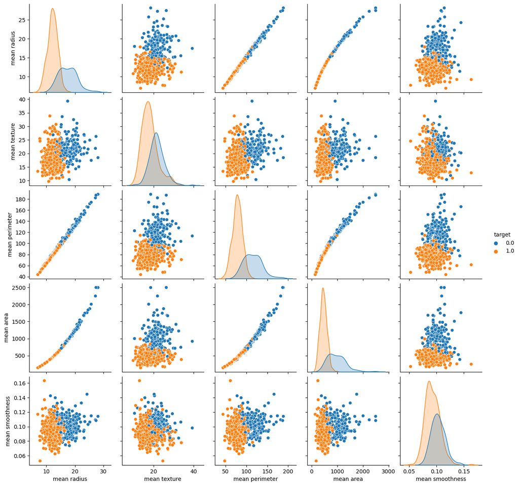

```python
sns.pairplot(df, hue = 'target', vars = ['mean radius', 'mean texture', 'mean perimeter', 'mean area',
       'mean smoothness'] )
```

These visualizations of different features helps us understand the bariability and distribution of different featutres in the data.

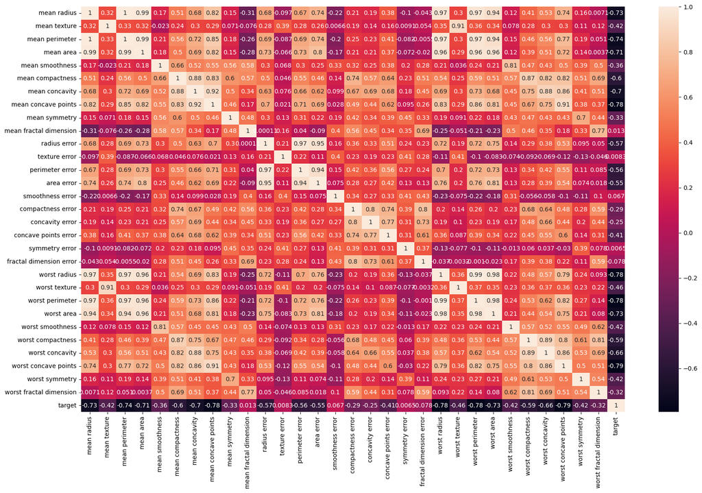

```python
plt.figure(figsize=(20,12))
sns.heatmap(df.corr(), annot=True)
```

Using the correltion heatmap above, we can infer that there is a high correlation between mean area and mean perimeter. Also mean radius and mean perimater are high correlated as well. Which is expected because radius is needed to calculate area and perimeter.

```python
# X = df.loc[:, df.columns != 'target'].values[:, 1:]
# y = df.loc[:, 'target'].values
# print(X.shape)
# print(y.shape)
X = df.drop(['target'], axis = 1)
X.head()
```

|  | mean radius | mean texture | mean perimeter | mean area | mean smoothness | mean compactness | mean concavity | mean concave points | mean symmetry | mean fractal dimension | ... | worst radius | worst texture | worst perimeter | worst area | worst smoothness | worst compactness | worst concavity | worst concave points | worst symmetry | worst fractal dimension |
| --- | --- | --- | --- | --- | --- | --- | --- | --- | --- | --- | --- | --- | --- | --- | --- | --- | --- | --- | --- | --- | --- |
| 0 | 17.99 | 10.38 | 122.80 | 1001.0 | 0.11840 | 0.27760 | 0.3001 | 0.14710 | 0.2419 | 0.07871 | ... | 25.38 | 17.33 | 184.60 | 2019.0 | 0.1622 | 0.6656 | 0.7119 | 0.2654 | 0.4601 | 0.11890 |
| 1 | 20.57 | 17.77 | 132.90 | 1326.0 | 0.08474 | 0.07864 | 0.0869 | 0.07017 | 0.1812 | 0.05667 | ... | 24.99 | 23.41 | 158.80 | 1956.0 | 0.1238 | 0.1866 | 0.2416 | 0.1860 | 0.2750 | 0.08902 |
| 2 | 19.69 | 21.25 | 130.00 | 1203.0 | 0.10960 | 0.15990 | 0.1974 | 0.12790 | 0.2069 | 0.05999 | ... | 23.57 | 25.53 | 152.50 | 1709.0 | 0.1444 | 0.4245 | 0.4504 | 0.2430 | 0.3613 | 0.08758 |
| 3 | 11.42 | 20.38 | 77.58 | 386.1 | 0.14250 | 0.28390 | 0.2414 | 0.10520 | 0.2597 | 0.09744 | ... | 14.91 | 26.50 | 98.87 | 567.7 | 0.2098 | 0.8663 | 0.6869 | 0.2575 | 0.6638 | 0.17300 |
| 4 | 20.29 | 14.34 | 135.10 | 1297.0 | 0.10030 | 0.13280 | 0.1980 | 0.10430 | 0.1809 | 0.05883 | ... | 22.54 | 16.67 | 152.20 | 1575.0 | 0.1374 | 0.2050 | 0.4000 | 0.1625 | 0.2364 | 0.07678 |

5 rows × 30 columns

```python
y = df['target']
y.head()
```

```
0    0.0
1    0.0
2    0.0
3    0.0
4    0.0
Name: target, dtype: float64
```

We now perform the pre-processing steps by implementing the MinMax scaler and StandardScaler. It is always a good step to perform this step as scaling the values in a specfic range (in our case 0,1) helps us ensure that all data features contribute equally to the model. Then we perform the standard scaler optmization step. In this step we standardize all the features in our dataset by removing the mean and scaling to unit variance. This helps us scale the data to assume a standard normal distribution for all features which helps in reducing the impact of outliers in the data.

```python
scaler=MinMaxScaler()
X=scaler.fit_transform(X)
scaler = StandardScaler()
X = scaler.fit_transform(X)
```

Next we perform the 80-20 split for train and test datasets.

```python
from sklearn.model_selection import train_test_split
X_train, X_test, y_train, y_test = train_test_split(X, y, train_size = 0.8, random_state=42)
print (X_train.shape)
print (X_test.shape)
print (y_train.shape)
print (y_test.shape)
```

```
(455, 30)
(114, 30)
(455,)
(114,)
```

We now initialize our SVM model as below and print the weighted accuracy, precision, recall and f-1 scores.

```python
model_SVC = SVC()
model_SVC.fit(X_train, y_train)
svc_predictions = model_SVC.predict(X_test)

print("Accuracy:", metrics.accuracy_score(y_test, svc_predictions))
print("Precision:", metrics.precision_score(y_test, svc_predictions, average = 'weighted'))
print("Recall:", metrics.recall_score(y_test, svc_predictions, average = 'weighted'))
print("F1-score:", metrics.f1_score(y_test, svc_predictions, average = 'weighted'))
```

```
Accuracy: 0.9736842105263158
Precision: 0.9737190197716513
Recall: 0.9736842105263158
F1-score: 0.9736214250146138
```

Based on the classification report, we have achieved a high accuracy of over 97% using the SVM classification model.

```python
print(classification_report(y_test, svc_predictions))
```

```
              precision    recall  f1-score   support

         0.0       0.98      0.95      0.96        43
         1.0       0.97      0.99      0.98        71

    accuracy                           0.97       114
   macro avg       0.97      0.97      0.97       114
weighted avg       0.97      0.97      0.97       114
```

Next, we visualize our results using a confusion matrix. We see that then model wrongly classified patients with cancer as normal patients twice. And, for one data point it classified the patient as cancerous when they were not.

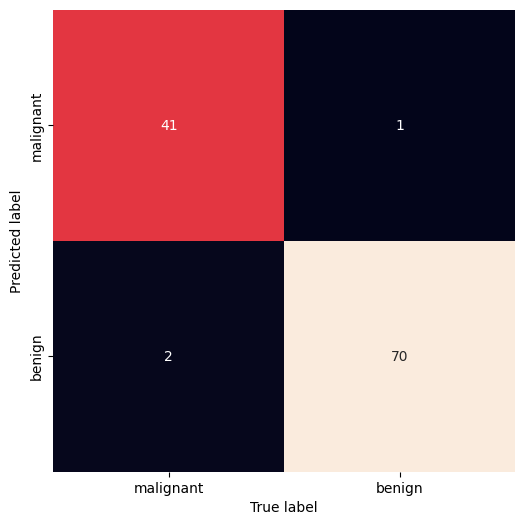

```python
plt.figure(figsize=(8,6))
mat = confusion_matrix(y_test, svc_predictions)
sns.heatmap(mat.T, square=True, annot=True, fmt='d', cbar=False, xticklabels=breast_cancer.target_names, yticklabels=breast_cancer.target_names)
plt.xlabel('True label')
plt.ylabel('Predicted label')
```

we use the below line to get all the parameters

```python
parameters = model_SVC.get_params()
parameters
```

```
{'C': 1.0,
 'break_ties': False,
 'cache_size': 200,
 'class_weight': None,
 'coef0': 0.0,
 'decision_function_shape': 'ovr',
 'degree': 3,
 'gamma': 'scale',
 'kernel': 'rbf',
 'max_iter': -1,
 'probability': False,
 'random_state': None,
 'shrinking': True,
 'tol': 0.001,
 'verbose': False}
```

Now we provide a specific range for all relevant paramters to be able to perform the Grid Search which will provide us with the most optimal hyperparameter values.

```python
parameter_grid = [{'C': [0.5, 0.1, 1, 5, 10, 100], 'kernel': ['linear'], 'class_weight': ['balanced']},
                  {'C': [0.5, 0.1, 1, 5, 10, 100], 'kernel': ['poly'], 'class_weight': ['balanced']},
                  {'C': [0.5, 0.1, 1, 5, 10, 100], 'gamma': [0.0001, 0.001, 0.01, 0.1, 0.005, 0.05, 0.5], 'kernel': ['rbf'], 'class_weight': ['balanced']}]
# [{'C': [0.5, 0.1, 1, 5, 10, 100], 'kernel': ['linear'], 'class_weight': ['balanced']},
            #   {'C': [0.5, 0.1, 1, 5, 10, 100], 'gamma': [0.0001, 0.001, 0.01, 0.1, 0.005, 0.05, 0.5], 'kernel': ['rbf'], 'class_weight': ['balanced']}]
```

```python
svc_grs = GridSearchCV(model_SVC, parameter_grid) # building the grid search
svc_grs.fit(X_train, y_train) #using the training dataset
```

```
GridSearchCV(estimator=SVC(),
             param_grid=[{'C': [0.5, 0.1, 1, 5, 10, 100],
                          'class_weight': ['balanced'], 'kernel': ['linear']},
                         {'C': [0.5, 0.1, 1, 5, 10, 100],
                          'class_weight': ['balanced'], 'kernel': ['poly']},
                         {'C': [0.5, 0.1, 1, 5, 10, 100],
                          'class_weight': ['balanced'],
                          'gamma': [0.0001, 0.001, 0.01, 0.1, 0.005, 0.05, 0.5],
                          'kernel': ['rbf']}])
```

```python
#getting the best values for the relevant parameters
print("Best Hyper Parameters:", svc_grs.best_params_)
print("Best estimator:", svc_grs.best_estimator_)
```

```
Best Hyper Parameters: {'C': 5, 'class_weight': 'balanced', 'gamma': 0.01, 'kernel': 'rbf'}
Best estimator: SVC(C=5, class_weight='balanced', gamma=0.01)
```

```python
best_svc_model = svc_grs.best_estimator_
#making predictions on the test data after hyperparameter tuning
best_svc_predictions = best_svc_model.predict(X_test)

print("Accuracy:", metrics.accuracy_score(y_test, best_svc_predictions))
print("Precision:", metrics.precision_score(y_test, best_svc_predictions, average = 'weighted'))
print("Recall:", metrics.recall_score(y_test, best_svc_predictions, average = 'weighted'))
print("F1-score:", metrics.f1_score(y_test, best_svc_predictions, average = 'weighted'))
```

```
Accuracy: 0.9824561403508771
Precision: 0.9829367940398942
Recall: 0.9824561403508771
F1-score: 0.9823691172375383
```

```python
print(classification_report(y_test, best_svc_predictions))
```

```
              precision    recall  f1-score   support

         0.0       1.00      0.95      0.98        43
         1.0       0.97      1.00      0.99        71

    accuracy                           0.98       114
   macro avg       0.99      0.98      0.98       114
weighted avg       0.98      0.98      0.98       114
```

We now have an even more improved result with over 98% overall accuracy. The case where one data point which classified the patient as cancerous when they were not is eliminated. But after the hyperparameter optimization steps there are still 2 cases where the patient was cancerous but was predicted as non cancerous.

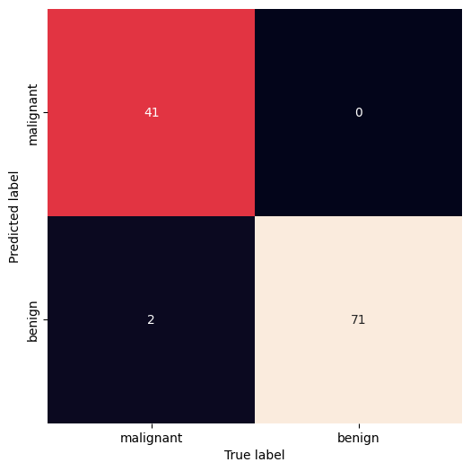

```python
plt.figure(figsize=(8,6))
mat = confusion_matrix(y_test, best_svc_predictions)
sns.heatmap(mat.T, square=True, annot=True, fmt='d', cbar=False, xticklabels=breast_cancer.target_names, yticklabels=breast_cancer.target_names)
plt.xlabel('True label')
plt.ylabel('Predicted label')
```

Below are additional steps to implement the RandomSearchCV. These are just exploratory steps for learning that helpded ensure that GridSearchCV produces the most optimal hyperprameter tuning in this case.

```python
from scipy.stats import expon, uniform
# hi_param_dist = {
#     'C': expon(scale=1),          # Regularization parameter C (exponential distribution)
#     'kernel': ['linear', 'rbf'],  # Kernel types to consider
#     'gamma': uniform(0, 1)       # Kernel coefficient for 'rbf' (uniform distribution)
# }
hi_param_dist = [{'C': [0.5, 0.1, 1, 5, 10, 100], 'kernel': ['linear'], 'class_weight': ['balanced']},
                 {'C': [0.5, 0.1, 1, 5, 10, 100], 'kernel': ['poly'], 'class_weight': ['balanced']},
              {'C': [0.5, 0.1, 1, 5, 10, 100], 'gamma': [0.0001, 0.001, 0.01, 0.1, 0.005, 0.05, 0.5], 'kernel': ['rbf'], 'class_weight': ['balanced']}]
# Create a RandomizedSearchCV object
hi = RandomizedSearchCV(model_SVC, param_distributions=hi_param_dist, n_iter=10, cv=5, n_jobs=-1, random_state=42)
# hi = RandomizedSearchCV(model_SVC)
hi.fit(X_train, y_train)
print("Best Hyper Parameters:", hi.best_params_)
print("Best estimator:", hi.best_estimator_)
```

```
Best Hyper Parameters: {'kernel': 'rbf', 'gamma': 0.005, 'class_weight': 'balanced', 'C': 1}
Best estimator: SVC(C=1, class_weight='balanced', gamma=0.005)
```

a lower overall accuracy was just a double check

```python
#bulid model is parameters generated by RandomSearchCV
hi_model = hi.best_estimator_
hi_predictions = hi_model.predict(X_test)

print("Accuracy:", metrics.accuracy_score(y_test, hi_predictions))
print("Precision:", metrics.precision_score(y_test, hi_predictions, average = 'weighted'))
print("Recall:", metrics.recall_score(y_test, hi_predictions, average = 'weighted'))
print("F1-score:", metrics.f1_score(y_test, hi_predictions, average = 'weighted'))
```

```
Accuracy: 0.9736842105263158
Precision: 0.9739576213260425
Recall: 0.9736842105263158
F1-score: 0.973742132293316
```

## Decision Tree

We now model the Decision tree classifier for the breast cancer dataset.

```python
DT_model = DecisionTreeClassifier()
DT_model.fit(X_train,y_train)
dt_predictions = DT_model.predict(X_test)

print("Accuracy:", metrics.accuracy_score(y_test, dt_predictions))
print("Precision:", metrics.precision_score(y_test, dt_predictions, average = 'weighted'))
print("Recall:", metrics.recall_score(y_test, dt_predictions, average = 'weighted'))
print("F1-score:", metrics.f1_score(y_test, dt_predictions, average = 'weighted'))
```

```
Accuracy: 0.9385964912280702
Precision: 0.938457254246728
Recall: 0.9385964912280702
F1-score: 0.9384499917007656
```

We can notice a lower overall accuracy

```python
report = classification_report(y_test, dt_predictions, target_names = breast_cancer.target_names)
print(report)
```

```
              precision    recall  f1-score   support

   malignant       0.93      0.91      0.92        43
      benign       0.94      0.96      0.95        71

    accuracy                           0.94       114
   macro avg       0.94      0.93      0.93       114
weighted avg       0.94      0.94      0.94       114
```

We now perform hyperparameter tuning for Decision Tree classifier using the GridSearchCV method.

```python
parameters_dt = {'criterion': ['gini', 'entropy'], 'max_depth': range(1,10)}
dt_grs = GridSearchCV(DT_model, param_grid=parameters_dt, cv = 10) #use 10-fold instead of the default 5-fold
dt_grs.fit(X_train, y_train)
```

```
GridSearchCV(cv=10, estimator=DecisionTreeClassifier(),
             param_grid={'criterion': ['gini', 'entropy'],
                         'max_depth': range(1, 10)})
```

We print the best hyperparameters achieved below

```python
print("Best Hyper Parameters:", dt_grs.best_params_)
print("Best estimator:", dt_grs.best_estimator_)
```

```
Best Hyper Parameters: {'criterion': 'gini', 'max_depth': 3}
Best estimator: DecisionTreeClassifier(max_depth=3)
```

```python
#now we make predictions using the best parameters on the test set.
best_dt_model = dt_grs.best_estimator_
best_dt_predictions = best_dt_model.predict(X_test)

#we plot the accuracy results by comparing the predictions to true values
print("Accuracy:", metrics.accuracy_score(y_test, best_dt_predictions))
print("Precision:", metrics.precision_score(y_test, best_dt_predictions, average = 'weighted'))
print("Recall:", metrics.recall_score(y_test, best_dt_predictions, average = 'weighted'))
print("F1-score:", metrics.f1_score(y_test, best_dt_predictions, average = 'weighted'))
```

```
Accuracy: 0.9473684210526315
Precision: 0.9474739303990012
Recall: 0.9473684210526315
F1-score: 0.947107351712615
```

```python
report = classification_report(y_test, best_dt_predictions, target_names = breast_cancer.target_names)
print(report)
```

```
              precision    recall  f1-score   support

   malignant       0.95      0.91      0.93        43
      benign       0.95      0.97      0.96        71

    accuracy                           0.95       114
   macro avg       0.95      0.94      0.94       114
weighted avg       0.95      0.95      0.95       114
```

Lastly we plot the actual descriptive decision tree that was used to reach the solution

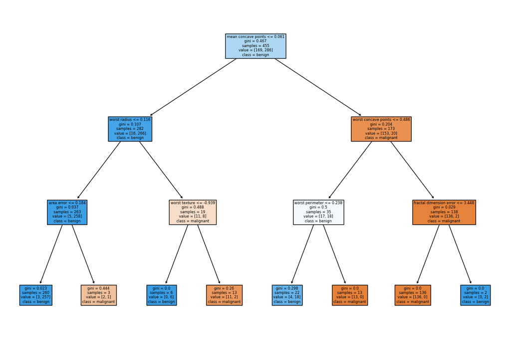

```python
fig = plt.figure(figsize=(15,10))
_ = tree.plot_tree(best_dt_model,filled=True, feature_names=breast_cancer.feature_names, class_names=breast_cancer.target_names)
```

### 3. (f) Decision Tree vs SVM

After performing the accuracy analysis using a classification report we can without a doubt choose SVM over decision tree because:

- The overall accuracy achieved by SVm is 98% compared to 95% achieved by decision trees.
- The values achived by SVMs (1.00 and 0.97) are higher than that achived by decision tree (0.95, 0.95)
- The recall values achieved by SVMs are also higher (0.95 and 1.00) when compared to that of DT (0.91 and 0.97). A higher value for recall basically refers to a lower rate of false negatives.
- The F1-score is higher for both classes in the SVM model which indicates a better balance between precision and recall.

Thus, visualizing the results after performing the hyperparameter training and predicting the results on the test set, we can deduce that SVM has a better overall performance than Decision Trees for the breast cancer classification problem. SVM performed better because it is able to handle more complex, high dimensional data with better accuracy and because it has strong generalization and regularization capabilities. Also, extensive hyperparamter tuning is available in svms when compared to decision treees. The kernel function choices avaialbe to optimize the algotihm to the problem at hand is the game changer. By manually choosing how the data is manipulated thus helps achieve a better accuracy.

### References

baeldung 2020, Multiclass Classification Using Support Vector Machines | Baeldung on Computer Science, www.baeldung.com.

CV, G 2019, sklearn.model_selection.GridSearchCV — scikit-learn 0.22 documentation, Scikit-learn.org.

dataset, sklearn n.d., sklearn.datasets.load_breast_cancer, scikit-learn, viewed 11 October 2023, https://scikit-learn.org/stable/modules/generated/sklearn.datasets.load_breast_cancer.html#examples-using-sklearn-datasets-load-breast-cancer.

GeeksForGeeks 2017, Decision Tree - GeeksforGeeks, GeeksforGeeks.

Gupta, B 2023, Non-Linear SVM, Scaler Topics.

Lamidi, A 2018, Breast Cancer Classification Using Support Vector Machine (SVM), Medium.

Marius, H 2020, Multiclass Classification with Support Vector Machines (SVM), Kernel Trick & Kernel Functions, Medium.

randomized, grid vs n.d., Comparing randomized search and grid search for hyperparameter estimation, scikit-learn, viewed 11 October 2023, https://scikit-learn.org/stable/auto_examples/model_selection/plot_randomized_search.html#sphx-glr-auto-examples-model-selection-plot-randomized-search-py.

scikit-learn 2009, 1.10. Decision Trees — scikit-learn 0.22 documentation, Scikit-learn.org.

Sklearn n.d., 1.4. Support Vector Machines — scikit-learn 0.23.2 documentation, scikit-learn.org.

UCI n.d., UCI Machine Learning Repository, archive.ics.uci.edu.

Works, M 2023, Support Vector Machine (SVM) Explained, au.mathworks.com.

Yadav, S 2023, What is Kernel Trick in SVM ? Interview questions related to Kernel Trick, Medium, viewed 11 October 2023, https://medium.com/@Suraj_Yadav/what-is-kernel-trick-in-svm-interview-questions-related-to-kernel-trick-97674401c48d#:~:text=The%20polynomial%20kernel%20is%20a.